# template QA

Emma Wood

**Run date and time: 2022-10-17 10:45:01**

## Introduction

The source data for 11-1-1 are on two spreadsheets and each year is given on a separate tab. Updating the indicator and making sure revisions are spotted therefore takes quite a long time.

In addition, not all possible disaggregations were included on the platform before this automation. This may be partly due to the time consuming nature of including all variables.

This file runs some basic checks on the csv output and highlights some specific things that should manually be checked.

Data in the csv are labelled as ‘Normal data’ in the Observation status column. However, notes should be checked in the spreadsheet to ensure this is correct for new data.

## Configurations

There are two series for this indicator, which are stored in separate files:  
- filepath for the ‘dwellings’ data: **D:/coding_repos/sdg_data_updates/11-1-1/Example_input/Example_areas.xlsx**  
- filepath for the ‘households’ data: **D:/coding_repos/sdg_data_updates/11-1-1/Example_input/Example_households.xlsx**

There are multiple headers, however all the information we need for column names is on the header just above the values. The row on which this header is found is set using the ‘header_row’ arguments in the config file:  
- row number of the column names for dwellings data: **5**  
- row number of the column names for households data: **5**

There is a tab for each year. Which years to run is set in the configs. For this run the following tabs were set to run: **2019, 2020**

Location of the outputs: **D:/coding_repos/sdg_data_updates/11-1-1/Example_output**

## Plots and tables

Please check the plots and tables below for any differences between the live data (which is pulled in from Github) and the new data.

If there are zig-zag lines or plots look unusual there may be something different in the source data that is causing an issue. This will need to be investigated.

The table below each plot shows all instances where the old (live) value does not match the new value. It is sorted so the largest absolute differences appear first, but can be sorted in other ways using the arrows at the top.

## Differences between live and new data

tiny differences may just be due to differences in rounding, which is not an issue.  
Larger differences may be due to revisions, but could also indicate an error in the code.  
**If there are differences larger than 0.05 please check that new data match source**

### Series: Dwellings

#### Decent homes criteria by urbanisation sub-category

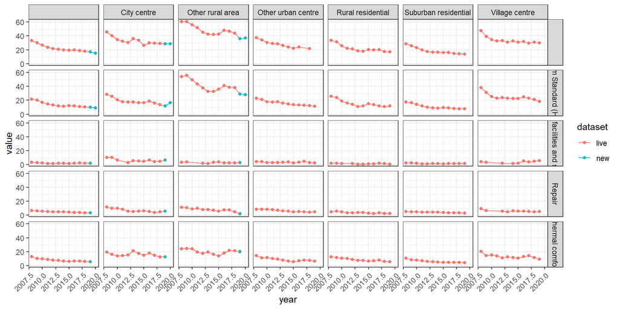

| year | series | disagg_combo | live | new | difference |
| --- | --- | --- | --- | --- | --- |
| 2019 | Dwellings (%) | Minimum Standard (HHSRS) , | 9.89529981747814 | 9.9 | 0.00470018252186044 |
| 2019 | Dwellings (%) | Thermal comfort , City centre | 12.384452419041 | 12.38 | -0.0044524190409998 |
| 2019 | Dwellings (%) | Repair , City centre | 5.49563627604183 | 5.5 | 0.00436372395817042 |
| 2019 | Dwellings (%) | Repair , Other rural area | 2.03376587453786 | 2.03 | -0.00376587453786037 |
| 2019 | Dwellings (%) | Minimum Standard (HHSRS) , Other rural area | 29.073270607492 | 29.07 | -0.00327060749199859 |
| 2019 | Dwellings (%) | Modern facilities and services , | 2.12265171101914 | 2.12 | -0.00265171101913975 |
| 2019 | Dwellings (%) | Modern facilities and services , Other rural area | 2.85260472881933 | 2.85 | -0.00260472881933005 |
| 2019 | Dwellings (%) | Thermal comfort , | 5.60740524103036 | 5.61 | 0.00259475896964023 |
| 2019 | Dwellings (%) | Modern facilities and services , City centre | 6.70228470133352 | 6.7 | -0.00228470133351966 |
| 2019 | Dwellings (%) | Thermal comfort , Other rural area | 20.1621423550563 | 20.16 | -0.0021423550563 |

[output cut: 5 more lines]

#### Decent homes criteria by sub-national area

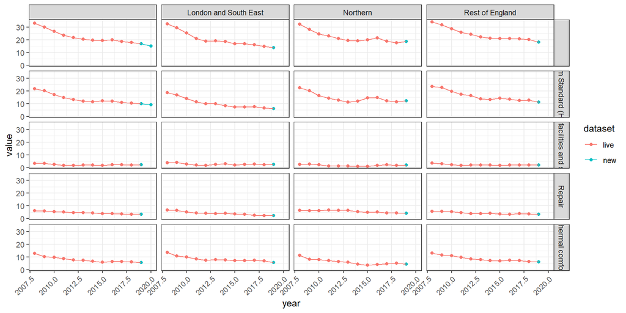

| year | series | disagg_combo | live | new | difference |
| --- | --- | --- | --- | --- | --- |
| 2019 | Dwellings (%) | Minimum Standard (HHSRS) , | 9.89529981747814 | 9.9 | 0.00470018252186044 |
| 2019 | Dwellings (%) | Modern facilities and services , Rest of England | 2.05468993545417 | 2.05 | -0.00468993545417007 |
| 2019 | Dwellings (%) | Repair , Rest of England | 3.33553757291149 | 3.34 | 0.00446242708851008 |
| 2019 | Dwellings (%) | Thermal comfort , Northern | 4.51438643166137 | 4.51 | -0.00438643166136998 |
| 2019 | Dwellings (%) | , Northern | 18.6242594909203 | 18.62 | -0.00425949092029754 |
| 2019 | Dwellings (%) | , Rest of England | 18.1741115437951 | 18.17 | -0.00411154379509782 |
| 2019 | Dwellings (%) | Minimum Standard (HHSRS) , Rest of England | 11.1135300297154 | 11.11 | -0.00353002971540128 |
| 2019 | Dwellings (%) | Repair , Northern | 4.13325428666549 | 4.13 | -0.00325428666549055 |
| 2019 | Dwellings (%) | Modern facilities and services , Northern | 2.00696366676374 | 2.01 | 0.00303633323625974 |
| 2019 | Dwellings (%) | Modern facilities and services , | 2.12265171101914 | 2.12 | -0.00265171101913975 |

[output cut: 10 more lines]

#### Decent homes criteria by region

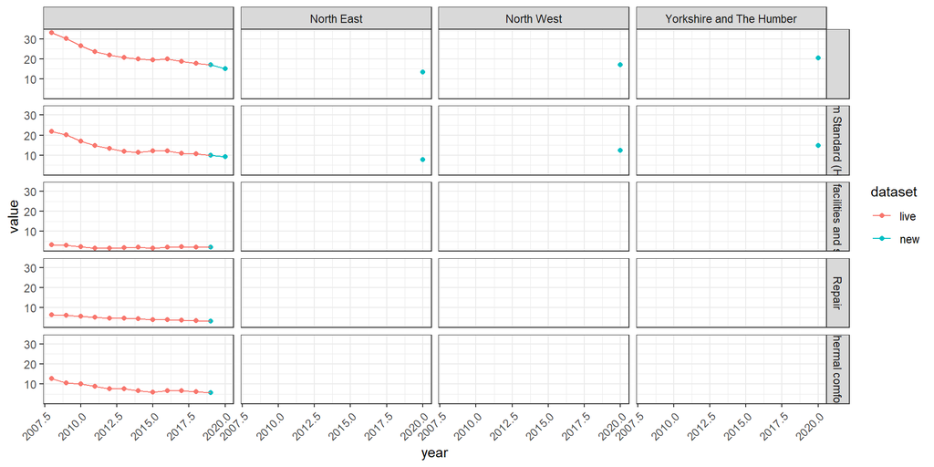

| year | series | disagg_combo | live | new | difference |
| --- | --- | --- | --- | --- | --- |
| 2019 | Dwellings (%) | Minimum Standard (HHSRS) , | 9.89529981747814 | 9.9 | 0.00470018252186044 |
| 2019 | Dwellings (%) | Modern facilities and services , | 2.12265171101914 | 2.12 | -0.00265171101913975 |
| 2019 | Dwellings (%) | Thermal comfort , | 5.60740524103036 | 5.61 | 0.00259475896964023 |
| 2019 | Dwellings (%) | Repair , | 3.31062460472721 | 3.31 | -0.000624604727209821 |
| 2019 | Dwellings (%) | , | 16.9893976780079 | 16.99 | 0.000602321992097643 |

#### Decent homes criteria by IMD

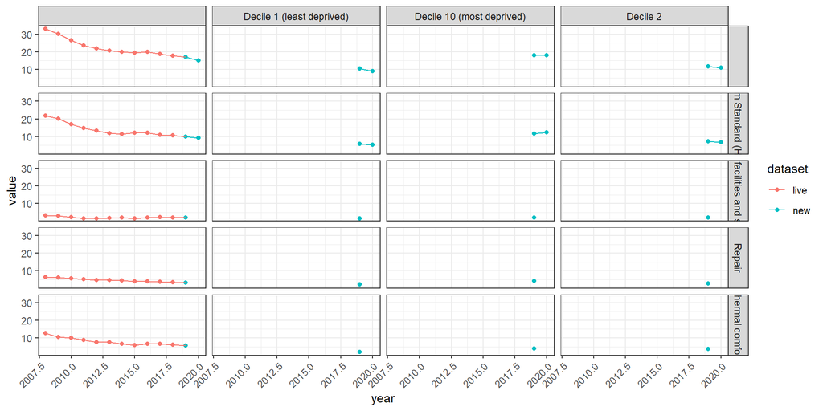

| year | series | disagg_combo | live | new | difference |
| --- | --- | --- | --- | --- | --- |
| 2019 | Dwellings (%) | Minimum Standard (HHSRS) , | 9.89529981747814 | 9.9 | 0.00470018252186044 |
| 2019 | Dwellings (%) | Modern facilities and services , | 2.12265171101914 | 2.12 | -0.00265171101913975 |
| 2019 | Dwellings (%) | Thermal comfort , | 5.60740524103036 | 5.61 | 0.00259475896964023 |
| 2019 | Dwellings (%) | Repair , | 3.31062460472721 | 3.31 | -0.000624604727209821 |
| 2019 | Dwellings (%) | , | 16.9893976780079 | 16.99 | 0.000602321992097643 |

### Series: Households

#### Decent homes criteria by age of oldest person

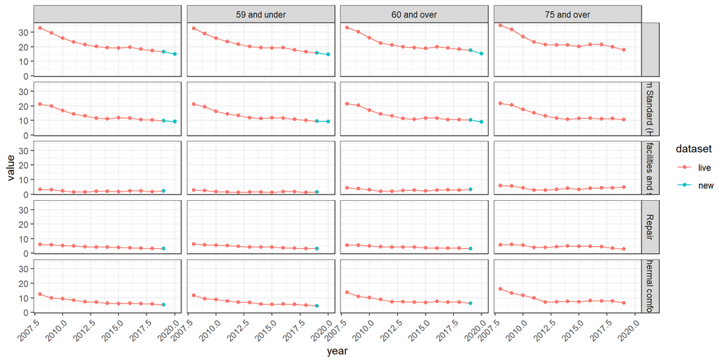

| year | series | disagg_combo | live | new | difference |
| --- | --- | --- | --- | --- | --- |
| 2019 | Households (%) | , | 16.5944101093786 | 16.59 | -0.00441010937860042 |
| 2019 | Households (%) | Thermal comfort , 60 and over | 6.33574192962176 | 6.34 | 0.00425807037824022 |
| 2019 | Households (%) | Modern facilities and services , 59 and under | 1.44422478772949 | 1.44 | -0.00422478772949009 |
| 2019 | Households (%) | Modern facilities and services , 60 and over | 3.1641914411663 | 3.16 | -0.00419144116629999 |
| 2019 | Households (%) | Repair , | 3.20389644874549 | 3.2 | -0.00389644874548978 |
| 2019 | Households (%) | , 59 and under | 15.9062049131597 | 15.91 | 0.0037950868403005 |
| 2019 | Households (%) | Repair , 59 and under | 3.13377727111514 | 3.13 | -0.00377727111514004 |
| 2019 | Households (%) | Minimum Standard (HHSRS) , | 9.78333767437582 | 9.78 | -0.00333767437582111 |
| 2019 | Households (%) | Minimum Standard (HHSRS) , 59 and under | 9.50292737540406 | 9.5 | -0.00292737540405952 |
| 2019 | Households (%) | Repair , 60 and over | 3.30745733191931 | 3.31 | 0.00254266808068992 |

[output cut: 5 more lines]

#### Decent homes criteria by age of youngest person

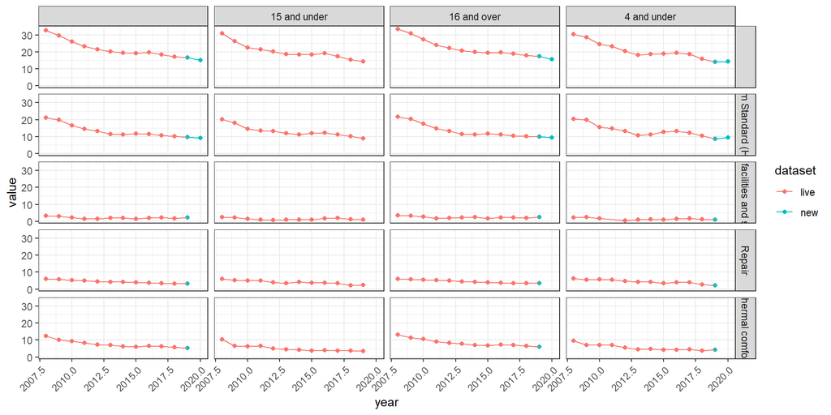

| year | series | disagg_combo | live | new | difference |
| --- | --- | --- | --- | --- | --- |
| 2019 | Households (%) | , | 16.5944101093786 | 16.59 | -0.00441010937860042 |
| 2019 | Households (%) | Modern facilities and services , 16 and over | 2.55567019853077 | 2.56 | 0.0043298014692299 |
| 2019 | Households (%) | Repair , | 3.20389644874549 | 3.2 | -0.00389644874548978 |
| 2019 | Households (%) | Repair , 16 and over | 3.45644830488185 | 3.46 | 0.00355169511815001 |
| 2019 | Households (%) | Thermal comfort , 4 and under | 4.09338800501363 | 4.09 | -0.00338800501363057 |
| 2019 | Households (%) | Minimum Standard (HHSRS) , | 9.78333767437582 | 9.78 | -0.00333767437582111 |
| 2019 | Households (%) | Minimum Standard (HHSRS) , 16 and over | 10.067311530046 | 10.07 | 0.00268846995400018 |
| 2019 | Households (%) | , 4 and under | 14.0126375881359 | 14.01 | -0.00263758813590087 |
| 2019 | Households (%) | Modern facilities and services , | 2.13862025680179 | 2.14 | 0.0013797431982101 |
| 2019 | Households (%) | Thermal comfort , | 5.25889652038009 | 5.26 | 0.00110347961990964 |

[output cut: 5 more lines]

#### Decent homes criteria by disability status (HH)

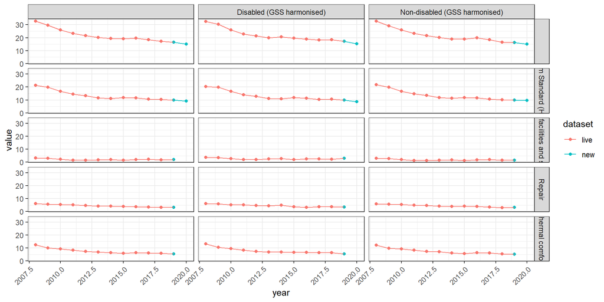

| year | series | disagg_combo | live | new | difference |
| --- | --- | --- | --- | --- | --- |
| 2019 | Households (%) | Thermal comfort , Non-disabled (GSS harmonised) | 5.16533912942171 | 5.17 | 0.00466087057828979 |
| 2019 | Households (%) | , | 16.5944101093786 | 16.59 | -0.00441010937860042 |
| 2019 | Households (%) | Repair , Non-disabled (GSS harmonised) | 3.12403085075216 | 3.12 | -0.00403085075216003 |
| 2019 | Households (%) | Repair , | 3.20389644874549 | 3.2 | -0.00389644874548978 |
| 2019 | Households (%) | Minimum Standard (HHSRS) , Non-disabled (GSS harmonised) | 9.8134292246694 | 9.81 | -0.0034292246694001 |
| 2019 | Households (%) | Minimum Standard (HHSRS) , | 9.78333767437582 | 9.78 | -0.00333767437582111 |
| 2019 | Households (%) | Modern facilities and services , Disabled (GSS harmonised) | 2.97242552757305 | 2.97 | -0.00242552757304981 |
| 2019 | Households (%) | Thermal comfort , Disabled (GSS harmonised) | 5.41217633982347 | 5.41 | -0.00217633982347021 |
| 2019 | Households (%) | , Non-disabled (GSS harmonised) | 16.1916047274264 | 16.19 | -0.00160472742640039 |
| 2019 | Households (%) | Modern facilities and services , Non-disabled (GSS harmonised) | 1.66142981101602 | 1.66 | -0.00142981101602002 |

[output cut: 5 more lines]

#### Decent homes criteria by ethnicity (HH)

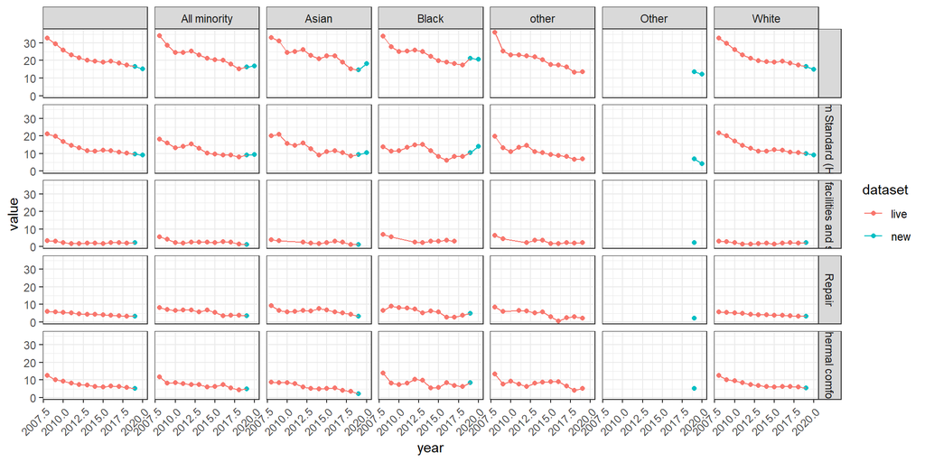

| year | series | disagg_combo | live | new | difference |
| --- | --- | --- | --- | --- | --- |
| 2019 | Households (%) | , White | 16.6249835517542 | 16.62 | -0.00498355175420073 |
| 2019 | Households (%) | Modern facilities and services , All minority | 1.20503281153075 | 1.21 | 0.00496718846924993 |
| 2019 | Households (%) | , | 16.5944101093786 | 16.59 | -0.00441010937860042 |
| 2019 | Households (%) | Repair , White | 3.16414697322641 | 3.16 | -0.00414697322640967 |
| 2019 | Households (%) | Minimum Standard (HHSRS) , White | 9.86586055443926 | 9.87 | 0.00413944556073886 |
| 2019 | Households (%) | Repair , | 3.20389644874549 | 3.2 | -0.00389644874548978 |
| 2019 | Households (%) | , All minority | 16.3438113612938 | 16.34 | -0.00381136129379911 |
| 2019 | Households (%) | Minimum Standard (HHSRS) , | 9.78333767437582 | 9.78 | -0.00333767437582111 |
| 2019 | Households (%) | Modern facilities and services , Asian | 1.08312212641291 | 1.08 | -0.00312212641290999 |
| 2019 | Households (%) | Minimum Standard (HHSRS) , All minority | 9.10692936620343 | 9.11 | 0.00307063379657002 |

[output cut: 14 more lines]

#### Decent homes criteria by income

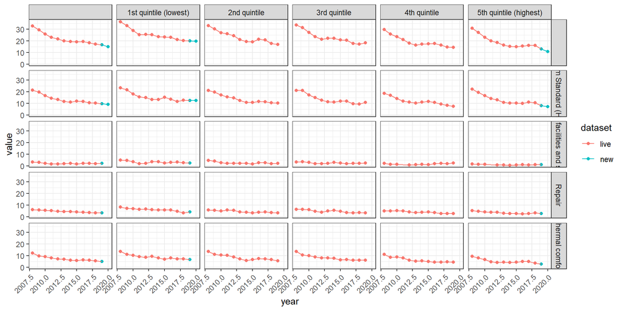

| year | series | disagg_combo | live | new | difference |
| --- | --- | --- | --- | --- | --- |
| 2019 | Households (%) | , | 16.5944101093786 | 16.59 | -0.00441010937860042 |
| 2019 | Households (%) | Repair , | 3.20389644874549 | 3.2 | -0.00389644874548978 |
| 2019 | Households (%) | Thermal comfort , 1st quintile (lowest) | 6.89624376731303 | 6.9 | 0.00375623268697023 |
| 2019 | Households (%) | Repair , 5th quintile (highest) | 2.71364910385038 | 2.71 | -0.00364910385038009 |
| 2019 | Households (%) | Repair , 1st quintile (lowest) | 4.09354016620499 | 4.09 | -0.00354016620499031 |
| 2019 | Households (%) | Minimum Standard (HHSRS) , | 9.78333767437582 | 9.78 | -0.00333767437582111 |
| 2019 | Households (%) | Minimum Standard (HHSRS) , 1st quintile (lowest) | 12.4218504155125 | 12.42 | -0.00185041551250009 |
| 2019 | Households (%) | Modern facilities and services , 5th quintile (highest) | 1.13182467456708 | 1.13 | -0.00182467456708002 |
| 2019 | Households (%) | Minimum Standard (HHSRS) , 5th quintile (highest) | 8.09852388221517 | 8.1 | 0.00147611778482926 |
| 2019 | Households (%) | Modern facilities and services , 1st quintile (lowest) | 2.4885540166205 | 2.49 | 0.00144598337950042 |

[output cut: 5 more lines]

#### Decent homes criteria by HH composition

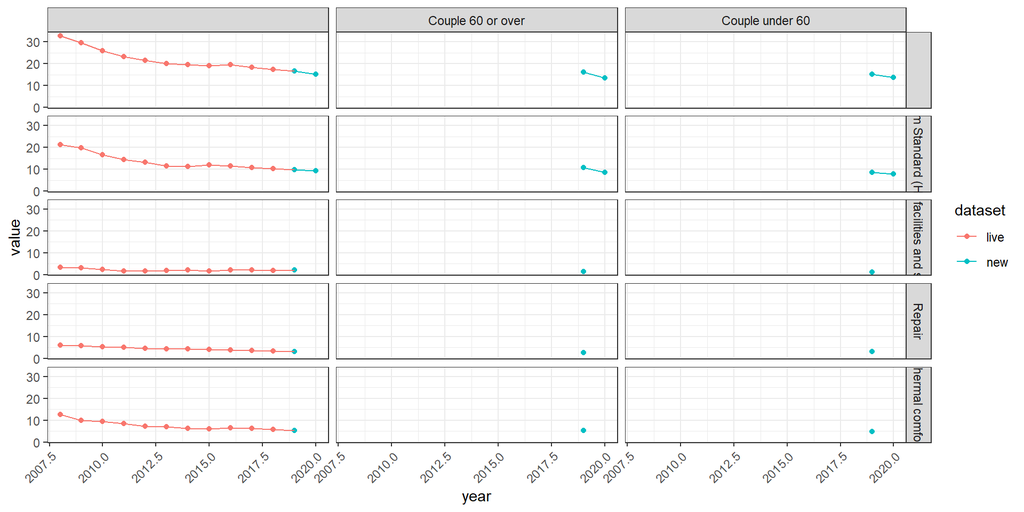

| year | series | disagg_combo | live | new | difference |
| --- | --- | --- | --- | --- | --- |
| 2019 | Households (%) | , | 16.5944101093786 | 16.59 | -0.00441010937860042 |
| 2019 | Households (%) | Repair , | 3.20389644874549 | 3.2 | -0.00389644874548978 |
| 2019 | Households (%) | Minimum Standard (HHSRS) , | 9.78333767437582 | 9.78 | -0.00333767437582111 |
| 2019 | Households (%) | Modern facilities and services , | 2.13862025680179 | 2.14 | 0.0013797431982101 |
| 2019 | Households (%) | Thermal comfort , | 5.25889652038009 | 5.26 | 0.00110347961990964 |

#### Decent homes criteria by length of residence

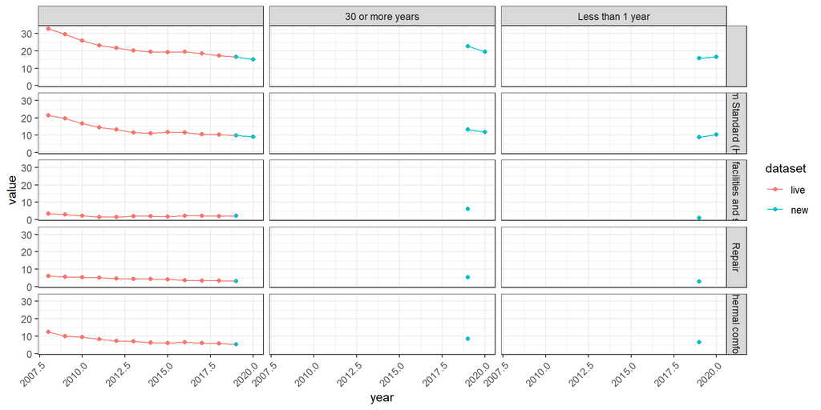

| year | series | disagg_combo | live | new | difference |
| --- | --- | --- | --- | --- | --- |
| 2019 | Households (%) | , | 16.5944101093786 | 16.59 | -0.00441010937860042 |
| 2019 | Households (%) | Repair , | 3.20389644874549 | 3.2 | -0.00389644874548978 |
| 2019 | Households (%) | Minimum Standard (HHSRS) , | 9.78333767437582 | 9.78 | -0.00333767437582111 |
| 2019 | Households (%) | Modern facilities and services , | 2.13862025680179 | 2.14 | 0.0013797431982101 |
| 2019 | Households (%) | Thermal comfort , | 5.25889652038009 | 5.26 | 0.00110347961990964 |

#### Decent homes criteria by poverty status

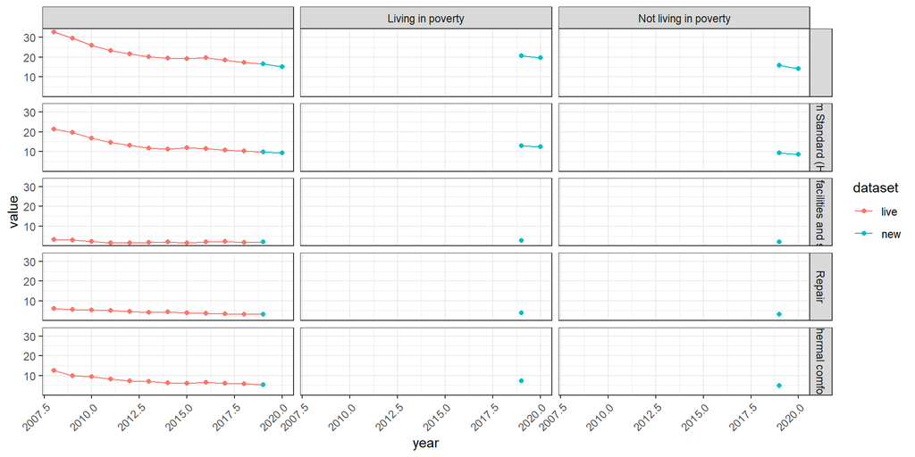

| year | series | disagg_combo | live | new | difference |
| --- | --- | --- | --- | --- | --- |
| 2019 | Households (%) | , | 16.5944101093786 | 16.59 | -0.00441010937860042 |
| 2019 | Households (%) | Repair , | 3.20389644874549 | 3.2 | -0.00389644874548978 |
| 2019 | Households (%) | Minimum Standard (HHSRS) , | 9.78333767437582 | 9.78 | -0.00333767437582111 |
| 2019 | Households (%) | Modern facilities and services , | 2.13862025680179 | 2.14 | 0.0013797431982101 |
| 2019 | Households (%) | Thermal comfort , | 5.25889652038009 | 5.26 | 0.00110347961990964 |

#### Decent homes criteria by workless HH

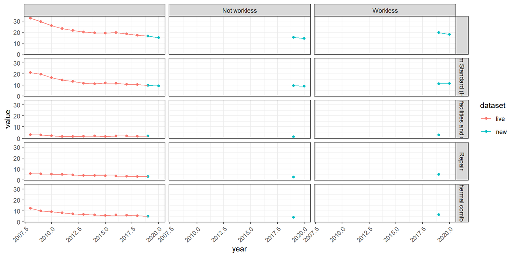

| year | series | disagg_combo | live | new | difference |
| --- | --- | --- | --- | --- | --- |
| 2019 | Households (%) | , | 16.5944101093786 | 16.59 | -0.00441010937860042 |
| 2019 | Households (%) | Repair , | 3.20389644874549 | 3.2 | -0.00389644874548978 |
| 2019 | Households (%) | Minimum Standard (HHSRS) , | 9.78333767437582 | 9.78 | -0.00333767437582111 |
| 2019 | Households (%) | Modern facilities and services , | 2.13862025680179 | 2.14 | 0.0013797431982101 |
| 2019 | Households (%) | Thermal comfort , | 5.25889652038009 | 5.26 | 0.00110347961990964 |

## Session Info

**R version 4.0.2 (2020-06-22)**

**Platform:** x86_64-w64-mingw32/x64 (64-bit)

**locale:** *LC_COLLATE=English_United Kingdom.1252*, *LC_CTYPE=English_United Kingdom.1252*, *LC_MONETARY=English_United Kingdom.1252*, *LC_NUMERIC=C* and *LC_TIME=English_United Kingdom.1252*

**attached base packages:** *stats*, *graphics*, *grDevices*, *utils*, *datasets*, *methods* and *base*

**other attached packages:** *pander(v.0.6.5)*, *DT(v.0.22)*, *ggplot2(v.3.3.5)*, *SDGupdater(v.0.0.0.9000)*, *stringr(v.1.4.0)*, *openxlsx(v.4.2.5)*, *tidyr(v.1.2.0)* and *dplyr(v.1.0.8)*

**loaded via a namespace (and not attached):** *tidyselect(v.1.1.2)*, *xfun(v.0.30)*, *bslib(v.0.3.1)*, *janitor(v.2.1.0)*, *purrr(v.0.3.4)*, *snakecase(v.0.11.0)*, *colorspace(v.2.0-3)*, *vctrs(v.0.4.1)*, *generics(v.0.1.2)*, *htmltools(v.0.5.2)*, *yaml(v.2.3.5)*, *utf8(v.1.2.2)*, *rlang(v.1.0.2)*, *pillar(v.1.7.0)*, *jquerylib(v.0.1.4)*, *glue(v.1.6.2)*, *withr(v.2.5.0)*, *DBI(v.1.1.2)*, *lifecycle(v.1.0.1)*, *munsell(v.0.5.0)*, *gtable(v.0.3.0)*, *zip(v.2.2.0)*, *htmlwidgets(v.1.5.4)*, *evaluate(v.0.15)*, *labeling(v.0.4.2)*, *knitr(v.1.38)*, *fastmap(v.1.1.0)*, *crosstalk(v.1.2.0)*, *fansi(v.1.0.3)*, *highr(v.0.9)*, *Rcpp(v.1.0.8.3)*, *scales(v.1.2.0)*, *jsonlite(v.1.7.0)*, *farver(v.2.1.0)*, *digest(v.0.6.29)*, *stringi(v.1.7.6)*, *grid(v.4.0.2)*, *cli(v.3.2.0)*, *tools(v.4.0.2)*, *magrittr(v.1.5)*, *sass(v.0.4.1)*, *tibble(v.3.1.6)*, *crayon(v.1.3.4)*, *pkgconfig(v.2.0.3)*, *ellipsis(v.0.3.2)*, *lubridate(v.1.8.0)*, *assertthat(v.0.2.1)*, *rmarkdown(v.2.13)*, *rstudioapi(v.0.13)*, *R6(v.2.4.1)* and *compiler(v.4.0.2)*